# Diverse dynamic redox fingerprints of single atom catalysts on ceria (100)

## Discussion - 18.03.2021

## 1. Nathan's work - Dynamic charge and oxidation state of Pt/CeO2 single-atom catalysts

## 1.1 Sampling

[figure not shown]

## 1.2 Origin of fine structure

[figure not shown]

## 1.3 Born-Haber

[figure not shown]

## 2. This work - Extension to group 9-11 metals (Co, Rh, Ir, Ni, Pd, Pt, Cu, Ag, Au)

## 2.1. Sampling results

[interactive chart not shown]

## 2.2 Statistical learning in materials science:

[figure not shown]

## Linear regression models:

Lasso (l1-regularization):

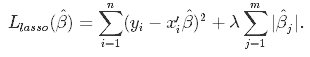

Ridge (l2-regularization):

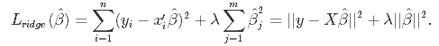

Elastic-net (l1 and l2):

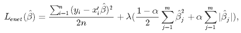

## 2.3. Descriptor overview

**Distances**

- Mean, min, max (from calculated structures):
  - M-O
  - M-bound O-ligands to neighboring Ce
  - M to surface Ce3
  - Ce3-Ce3

**Metal-descriptors**

**Indpendent variable**

- DFT-energy (global or per-metal ref.)

**References:**

- [1] Interaction trends between single metal atoms and oxide supports identified with density functional theory and statistical learning (https://doi.org/10.1038/s41929-018-0094-5) and references therein
- [2] webelements.com and references therein
- [3] Comprehensive handbook of chemical bond energies (https://doi.org/10.1201/9781420007282)
- [4] Taken from http://www.knowledgedoor.com/2/elements_handbook/cohesive_energy.html and references therein

## 2.4. Correlation

[interactive chart not shown]

## 2.5 PCA

[interactive chart not shown]

## 2.6. Lasso (2O and 4O coordinations)

[interactive chart not shown]

## 2.7. Principal component regression (PCR)

[interactive chart not shown]

## 2.8 Simple linear regression

[interactive chart not shown]

## 3. Conclusions and outlook

- System can be described with complex linear model
- Most of the variance can be captured with 8 principal components
- Feature selection with Lasso leads to loss of fine structure
- Complexity reduction of model
- Introduction of non-linearity (descriptor combinatorics/kernels)
- Predictive power (e.g. energy sampling on unrelaxed structures with previously trained model)

## 4. Additional results

## 4.1 t-SNE (t-distributed stochastic neighbor embedding)

[interactive chart not shown]